# CodelistGenerator options: examples with a with mock vocabulary

## Mock vocabulary database

Let´s say we have a mock vocabulary database with these hypothetical concepts and relationships.

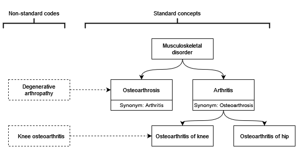

## Search for exact keyword match

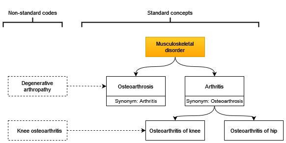

To find “Musculoskeletal disorder” we can search for that like so

```r
codes <- getCandidateCodes(
  cdm = cdm,
  keywords = "Musculoskeletal disorder",
  domains = "Condition",
  includeDescendants = FALSE,
)
```

```
#> Limiting to domains of interest
#> Getting concepts to include
#> Search completed. Finishing up.
#> ✔ 1 candidate concept identified
#>
#> Time taken: 0 minutes and 0 seconds
```

```r
codes |>
  glimpse()
```

```
#> Rows: 1
#> Columns: 6
#> $ concept_id       <int> 1
#> $ found_from       <chr> "From initial search"
#> $ concept_name     <chr> "Musculoskeletal disorder"
#> $ domain_id        <chr> "Condition"
#> $ vocabulary_id    <chr> "SNOMED"
#> $ standard_concept <chr> "S"
```

Note, we would also identify it based on a partial match

```r
codes <- getCandidateCodes(
  cdm = cdm,
  keywords = "Musculoskeletal",
  domains = "Condition",
  includeDescendants = FALSE
)
```

```
#> Limiting to domains of interest
#> Getting concepts to include
#> Search completed. Finishing up.
#> ✔ 1 candidate concept identified
#>
#> Time taken: 0 minutes and 0 seconds
```

```r
codes |>
  glimpse()
```

```
#> Rows: 1
#> Columns: 6
#> $ concept_id       <int> 1
#> $ found_from       <chr> "From initial search"
#> $ concept_name     <chr> "Musculoskeletal disorder"
#> $ domain_id        <chr> "Condition"
#> $ vocabulary_id    <chr> "SNOMED"
#> $ standard_concept <chr> "S"
```

## Add descendants

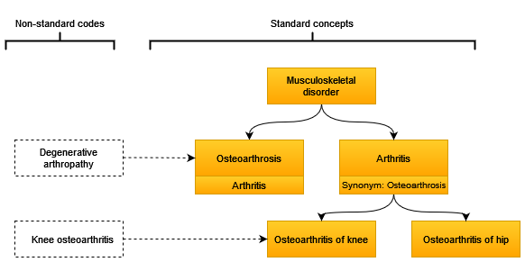

To include descendants of an identified code, we can set includeDescendants to TRUE

```r
getCandidateCodes(
  cdm = cdm,
  keywords = "Musculoskeletal disorder",
  domains = "Condition",
  includeDescendants = TRUE
) |>
  glimpse()
```

```
#> Limiting to domains of interest
#> Getting concepts to include
#> Adding descendants
#> Search completed. Finishing up.
#> ✔ 5 candidate concepts identified
#>
#> Time taken: 0 minutes and 0 seconds
#> Rows: 5
#> Columns: 6
#> $ concept_id       <int> 1, 2, 3, 4, 5
#> $ found_from       <chr> "From initial search", "From descendants", "From desc…
#> $ concept_name     <chr> "Musculoskeletal disorder", "Osteoarthrosis", "Arthri…
#> $ domain_id        <chr> "Condition", "Condition", "Condition", "Condition", "…
#> $ vocabulary_id    <chr> "SNOMED", "SNOMED", "SNOMED", "SNOMED", "SNOMED"
#> $ standard_concept <chr> "S", "S", "S", "S", "S"
```

## Multiple search terms

We can also search for multiple keywords at the same time, and would have picked these all up with the following search

```r
codes <- getCandidateCodes(
  cdm = cdm,
  keywords = c(
    "Musculoskeletal disorder",
    "arthritis",
    "arthrosis"
  ),
  domains = "Condition",
  includeDescendants = FALSE
)
```

```
#> Limiting to domains of interest
#> Getting concepts to include
#> Search completed. Finishing up.
#> ✔ 5 candidate concepts identified
#>
#> Time taken: 0 minutes and 0 seconds
```

```r
codes |>
  glimpse()
```

```
#> Rows: 5
#> Columns: 6
#> $ concept_id       <int> 1, 3, 4, 5, 2
#> $ found_from       <chr> "From initial search", "From initial search", "From i…
#> $ concept_name     <chr> "Musculoskeletal disorder", "Arthritis", "Osteoarthri…
#> $ domain_id        <chr> "Condition", "Condition", "Condition", "Condition", "…
#> $ vocabulary_id    <chr> "SNOMED", "SNOMED", "SNOMED", "SNOMED", "SNOMED"
#> $ standard_concept <chr> "S", "S", "S", "S", "S"
```

## Add ancestor

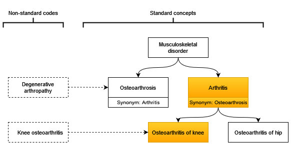

To include the ancestors one level above the identified concepts we can set includeAncestor to TRUE

```r
codes <- getCandidateCodes(
  cdm = cdm,
  keywords = "Osteoarthritis of knee",
  includeAncestor = TRUE,
  domains = "Condition"
)
```

```
#> Limiting to domains of interest
#> Getting concepts to include
#> Adding descendants
#> Adding ancestor
#> Search completed. Finishing up.
#> ✔ 2 candidate concepts identified
#>
#> Time taken: 0 minutes and 0 seconds
```

```r
codes |>
  glimpse()
```

```
#> Rows: 2
#> Columns: 6
#> $ concept_id       <int> 4, 3
#> $ found_from       <chr> "From initial search", "From ancestor"
#> $ concept_name     <chr> "Osteoarthritis of knee", "Arthritis"
#> $ domain_id        <chr> "Condition", "Condition"
#> $ vocabulary_id    <chr> "SNOMED", "SNOMED"
#> $ standard_concept <chr> "S", "S"
```

## Searches with multiple words

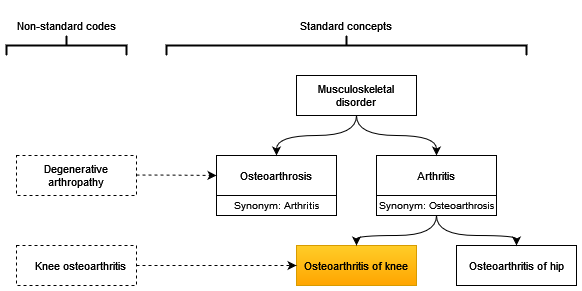

We can also find concepts with multiple words even if they are in a different order. For example, a search for “Knee osteoarthritis” will pick up “Osteoarthritis of knee”.

```r
codes <- getCandidateCodes(
  cdm = cdm,
  keywords = "Knee osteoarthritis",
  domains = "Condition",
  includeDescendants = TRUE
)
```

```
#> Limiting to domains of interest
#> Getting concepts to include
#> Adding descendants
#> Search completed. Finishing up.
#> ✔ 1 candidate concept identified
#>
#> Time taken: 0 minutes and 0 seconds
```

```r
codes |>
  glimpse()
```

```
#> Rows: 1
#> Columns: 6
#> $ concept_id       <int> 4
#> $ found_from       <chr> "From initial search"
#> $ concept_name     <chr> "Osteoarthritis of knee"
#> $ domain_id        <chr> "Condition"
#> $ vocabulary_id    <chr> "SNOMED"
#> $ standard_concept <chr> "S"
```

## With exclusions

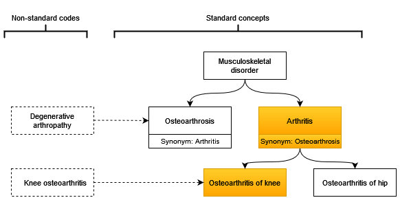

We can also exclude specific terms

```r
codes <- getCandidateCodes(
  cdm = cdm,
  keywords = "arthritis",
  exclude = "Hip osteoarthritis",
  domains = "Condition"
)
```

```
#> Limiting to domains of interest
#> Getting concepts to include
#> Adding descendants
#> Search completed. Finishing up.
#> ✔ 2 candidate concepts identified
#>
#> Time taken: 0 minutes and 0 seconds
```

```r
codes |>
  glimpse()
```

```
#> Rows: 2
#> Columns: 6
#> $ concept_id       <int> 3, 4
#> $ found_from       <chr> "From initial search", "From initial search"
#> $ concept_name     <chr> "Arthritis", "Osteoarthritis of knee"
#> $ domain_id        <chr> "Condition", "Condition"
#> $ vocabulary_id    <chr> "SNOMED", "SNOMED"
#> $ standard_concept <chr> "S", "S"
```

## Search using synonyms

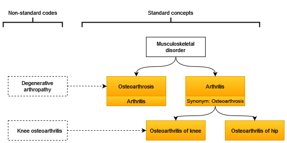

We can also pick up codes based on their synonyms. In this case “Arthritis” has a synonym of “Osteoarthrosis” and so a search of both the primary name of a concept and any of its associated synonyms would pick up this synonym and it would be included.

```r
codes <- getCandidateCodes(
  cdm = cdm,
  keywords = "osteoarthrosis",
  domains = "Condition",
  searchInSynonyms = TRUE
)
```

```
#> Limiting to domains of interest
#> Getting concepts to include
#> Adding concepts using synonymns
#> Adding descendants
#> Search completed. Finishing up.
#> ✔ 4 candidate concepts identified
#>
#> Time taken: 0 minutes and 0 seconds
```

```r
codes |>
  glimpse()
```

```
#> Rows: 4
#> Columns: 6
#> $ concept_id       <int> 2, 3, 4, 5
#> $ found_from       <chr> "From initial search", "In synonyms", "From descendan…
#> $ concept_name     <chr> "Osteoarthrosis", "Arthritis", "Osteoarthritis of kne…
#> $ domain_id        <chr> "Condition", "Condition", "Condition", "Condition"
#> $ vocabulary_id    <chr> "SNOMED", "SNOMED", "SNOMED", "SNOMED"
#> $ standard_concept <chr> "S", "S", "S", "S"
```

## Search via non-standard

Or we could have also picked up “Osteoarthrosis” by searching via non-standard.

```r
codes <- getCandidateCodes(
  cdm = cdm,
  keywords = c("arthritis", "arthropathy"),
  domains = "Condition",
  searchNonStandard = TRUE
)
```

```
#> Limiting to domains of interest
#> Getting concepts to include
#> Adding descendants
#> Adding codes from non-standard
#> Search completed. Finishing up.
#> ✔ 4 candidate concepts identified
#>
#> Time taken: 0 minutes and 0 seconds
```

```r
codes |>
  glimpse()
```

```
#> Rows: 4
#> Columns: 6
#> $ concept_id       <int> 3, 4, 5, 2
#> $ found_from       <chr> "From initial search", "From initial search", "From i…
#> $ concept_name     <chr> "Arthritis", "Osteoarthritis of knee", "Osteoarthriti…
#> $ domain_id        <chr> "Condition", "Condition", "Condition", "Condition"
#> $ vocabulary_id    <chr> "SNOMED", "SNOMED", "SNOMED", "SNOMED"
#> $ standard_concept <chr> "S", "S", "S", "S"
```

## Search for both standard and non-standard concepts

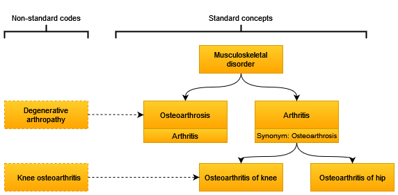

We can also include non-standard codes in our results like so

```r
codes <- getCandidateCodes(
  cdm = cdm,
  keywords = c(
    "Musculoskeletal disorder",
    "arthritis",
    "arthropathy",
    "arthrosis"
  ),
  domains = "Condition",
  standardConcept = c("Standard", "Non-standard")
)
```

```
#> Limiting to domains of interest
#> Getting concepts to include
#> Adding descendants
#> Search completed. Finishing up.
#> ✔ 8 candidate concepts identified
#>
#> Time taken: 0 minutes and 0 seconds
```

```r
codes |>
  glimpse()
```

```
#> Rows: 8
#> Columns: 6
#> $ concept_id       <int> 1, 3, 4, 5, 8, 17, 7, 2
#> $ found_from       <chr> "From initial search", "From initial search", "From i…
#> $ concept_name     <chr> "Musculoskeletal disorder", "Arthritis", "Osteoarthri…
#> $ domain_id        <chr> "Condition", "Condition", "Condition", "Condition", "…
#> $ vocabulary_id    <chr> "SNOMED", "SNOMED", "SNOMED", "SNOMED", "Read", "ICD1…
#> $ standard_concept <chr> "S", "S", "S", "S", NA, NA, NA, "S"
```